# 02 Selection

35762384

17/02/2021

#### Introduction

The availability of health facility data, such as location, capacity and resources present, is an important factor needed for decision-making processes, especially in the ongoing COVID-19 pandemic. Examples of uses include planning of interventions, disease surveillance, information for insurance companies and health management information systems (HMIS) (WHO, 2018). It is also often used for research purposes, with many studies utilising facility data to determine accessibility to healthcare or travel times (Hulland et al., 2019). However, availability is often not the issue but the fact that there are multiple sources and the discrepancies between them (Makinde et al., 2018). It is common for different organisations, e.g. non-governmental organisations (NGOs), government departments and other non-profit organisations, to produce their own lists and a need to further investigate differences is noted in studies using this data (Hulland, 2020). The aim of this paper is to do address this point; to analyse and highlight the differences between sources of facility data using Malawi as a case study and mark areas for improvement in the quality of the data.

One source for Malawi is a list compiled by the Kenyan Wellcome Trust Research Programme (KWTRP) for 50 sub-Saharan African countries and was released in 2019 (Maina et al., 2019). It focused on public health facilities, those run by the government, faith-based organisations (FBOs) and NGOs and also removed facilities that only provide specialised care such as psychiatry. It’s availability as open-access data as well as the thorough cleaning and validation processes implemented, meant it is often cited in other studies (Falchetta et al., 2020) (Judson et al., 2020) (Dowhaniuk, 2021) (Wariri et al., 2021). Several sources of information for facilities were combined to produce one list and in the case of Malawi, personal communication with health related organisations, data from The Humanitarian Data Exchange (HDX) and The Christian Health Association of Malawi (CHAM) were used (Maina et al., 2019). An important note is that the years of when the information was acquired from these sources vary, with the most recent being 2017 and the personal communication being conducted in 2013. The list is now being hosted by the World Health Organisation (WHO) Global Malaria Programme with the aim to update (WHO, 2019). However, since the publication of this study, there have been no updates or changes. Therefore, there is a need to compare with other sources, especially as the age of this data might mean new developments are not captured which could affect the study’s popularity.

A newer source is the Master Facility List (MFL) from and managed by the Malawi Ministry of Health (MOH, 2021). The WHO recommends that every country produces a MFL with the aim of it being the primary source and describes how to develop it in (WHO, 2019). It must be accessible, regularly updated and validated. Although many African countries have made steps towards formulating a MFL under these guidelines, issues of access and missing elements are often encountered, making its usage more difficult (South et al., 2021). With Malawi, the MFL is openly available.However, its validation methods are not made clear and information on the most recent update is only available when selecting a specific facility and is not part of the dataset that can be downloaded. Despite this, the fact that is maintained by the Ministry of Health and so has the potential to be incorporated into the health system and that it is a more recent source, it is worth investigating how this list compares to others.

Other sources are mostly dependent on information contributed by volunteers, of which healthsites.io is a global project aiming to map every health facility running (Healthsites, 2021). It works with OpenStreetMap, which provides the baseline map as well as the methods to input data, and since its establishment in 2016 has recorded over 900,000 facilities. Anyone can contribute and effort has been put into validation processes, which includes a Location Validation Index, a score that reflects other users verifying that facility exists. The data is freely available and access to the most recent version can be gained through several formats such as an API. Other lists can also be incorporated into healthsites.io and there is a process outlined for the import of facility lists from national ministries of health. However, similarly with other lists, it struggles with completeness and it has been shown that less than 2% of healthsites.io data for sub-Saharan Africa contains attributes describing capacity (South et al., 2021). It seems that the quality or functionality of these lists is limited across all of these sources.

Quality data is important but this is often neglected or not investigated. There are several issues that are prominent with facility data from sub-Saharan Africa. Lists are often missing key elements such as capacity, equipment and services they provide. Not only this, problems with missing coordinates can also occur, with the WHO-KWTRP data reporting 9 missing coordinates for Malawi (Maina et al., 2019). These issues are present but there is not much research highlighting this, especially when comparing between sources, but this is important for studies that go on to utilise these lists. The outbreak of COVID-19 brought a greater emphasis on the need for this. Several countries have allowed open access to their facility data, encouraging external research to aid the response to the pandemic and improvement of the data itself . For example, research investigating the ability of health facilities to increase capacity and the identification of people vulnerable due to various factors in Kenya were performed with open facility data (Barasa et al., 2020) (Macharia et al., 2020). Therefore, maintenance and quality control of facility lists are essential in providing accurate data and contributing to valid research.

The aim for this paper is to provide a reproducible summary of facility data for Malawi, discuss differences that are relevant to potential stakeholders and make apparent areas for improvement. The following hypotheses have been developed to address this:

1. The same number of health facility locations are recorded for Malawi across healthsites.io, WHO-KWTRP and their MFL
2. The health facility locations and proportion of facility types recorded in the Malawi MFL are similar to those being used in current global analyses
3. Hospital locations stored in healthsites.io are currently not a good representation of those available from the Malawi MFL

##### Results

In total, there are 1546 facilities recorded in the MFL and 648 in the WHO-KWTRP data. The MFL and the WHO-KWTRP lists contain 9 and 7 other attributes respectively in addition to coordinate data (figure 1). In the MFL, functional status of facilities, date opened and districts the facilities reside in are included. Two variations for the names are also stated while in the WHO-KWTRP list, there is one column for names and only first level administration regions for each facility are provided, which in Malawi consists of Northern, Central and Southern regions.

```
## # A tibble: 6 x 11
##   CODE  NAME  `COMMON NAME` OWNERSHIP TYPE  STATUS ZONE  DISTRICT `DATE OPENED`
##   <chr> <chr> <chr>         <chr>     <chr> <chr>  <chr> <chr>    <chr>
## 1 MC01… A + … A+A           Private   Clin… Funct… Cent… Mchinji  Jan 1st 75
## 2 BT24… A-C … A.C Opticals  Private   Clin… Funct… Sout… Blantyre Jan 1st 75
## 3 MZ16… A-C … A-C Opticals  Mission/… Clin… Non-f… Nort… Mzimba   Jan 1st 75
## 4 BT24… Akwe… Akwezeke Pvt  Private   Clin… Funct… Sout… Blantyre Jan 1st 75
## 5 BT24… AB M… Abowa         Private   Clin… Funct… Sout… Blantyre Jan 1st 75
## 6 LL04… ABC … ABC Clinic    Christia… Hosp… Funct… Cent… Lilongwe Jan 1st 75
## # … with 2 more variables: LATITUDE <chr>, LONGITUDE <chr>
```

```
## # A tibble: 6 x 9
##   Country Admin1 `Facility name` `Facility type` Ownership   Lat  Long
##   <chr>   <chr>  <chr>           <chr>           <chr>     <dbl> <dbl>
## 1 Malawi  Centr… 80 Block Clinic Clinic          MoH       -12.9  33.4
## 2 Malawi  Centr… ABC Community … Clinic          FBO       -14.0  33.7
## 3 Malawi  Centr… Adventist Heal… Health Centre   FBO       -14.0  33.8
## 4 Malawi  Centr… Alinafe Commun… Community Hosp… FBO       -13.4  34.2
## 5 Malawi  Centr… Area 18 Health… Health Centre   MoH       -13.9  33.8
## 6 Malawi  Centr… Area 25 Health… Health Centre   MoH       -13.9  33.8
## # … with 2 more variables: `LL source` <chr>, iso3c <chr>
```

- Facility plots

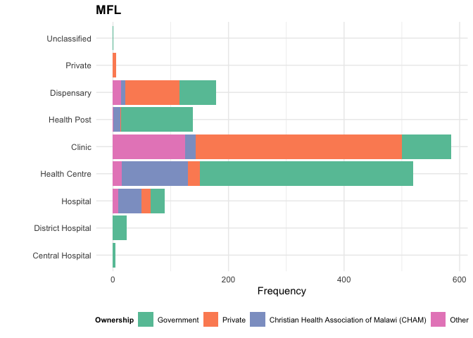

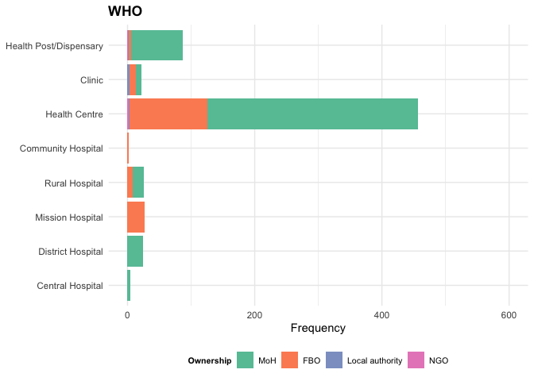

- Maps

[interactive chart not shown]

###### Missing values/wrong coordinates

- 181 in the MFL (this includes NA’s and coordinates that did not intersect with admin levels) and 9 in the WHO data. None are the same facilities/share same names.

```r
# MFL - 1546 before omitting NA's, then 1427.
# 62 coordinates did not intersect with admin data - now 1365

# using anti_join() to see which facilities were omitted
df_malawi_facilities_MFL = as.data.frame(malawi_facilities_MFL) # convert to data frame to use in anti_join

NA_MFL = anti_join(malawi_MFL, df_malawi_facilities_MFL) # 119 missing coordinates in MFL

# adding the number of wrong coordinates - 61
intersect_admin1_MFL = st_intersection(malawi_facilities_MFL, malawi_admin1) # returns data frame of matches

intersect_admin1_MFL = as.data.frame(intersect_admin1_MFL) # convert to data frame to use in anti_join

no_intersect_admin1_MFL = anti_join(malawi_facilities_MFL, intersect_admin1_MFL) # working out which facilities did not intersect

no_intersect_admin1_MFL_1 = no_intersect_admin1_MFL[ ,-c(10, 11)]
NA_MFL_1 = NA_MFL[, -c(10, 11)]
no_intersect_admin1_MFL_1 = st_set_geometry(no_intersect_admin1_MFL_1, NULL)
names(NA_MFL_1)[3] = "COMMON.NAME"
names(NA_MFL_1)[9] = "DATE.OPENED"

NA_MFL = rbind(NA_MFL_1, no_intersect_admin1_MFL_1) # combined dataframe of NA and wrong coordinates in MFL

# WHO - 648 with 9 missing coordinates, now 639
NA_WHO = anti_join(malawi_WHO, new_malawi_WHO)
```

###### Proportion that are privately owned in the MFL data

- 30.3% of facilities are privately owned (433/1427)
- Top 3 types are clinics (356), dispensaries (45) and hospitals (16)

```r
private_MFL = filter(malawi_facilities_MFL, OWNERSHIP == "Private")
# 433 private facilities, 30.3%

# which types are private?
private_MFL$TYPE = as.factor(private_MFL$TYPE)
types_private_MFL = as.data.frame(table(private_MFL$TYPE))
types_private_MFL
```

```
##            Var1 Freq
## 1        Clinic  356
## 2    Dispensary   45
## 3 Health Centre    9
## 4   Health Post    1
## 5      Hospital   16
## 6       Private    6
```

###### Duplicates within dataset

- 22 names in MFL appear more than once, of these Mpepa Health Centre (2 decimal places), Liwonde Medical Clinic (identical), Ngatala Health Post (3 decimal places), Cape Maclear (identical) and LIFE STYLE PVT CLINIC (identical) have similar/same coordinates
- Of these, Ngatala, Cape Maclear and LIFE STYLE PVT CLINIC are most likely the same entries as other attributes are also the same. The other facilities differ in type and so might not be duplicates.
- 10 names in WHO appear more than once, Mkango Health Centre has same coordinates (4 decimal places) and other attributes are also the same
- Duplicate coordinates: in the MFL, 44 coordinates have been repeated at least more than once.  
  Interesting note is that 24 facilities in Blantyre have reused the same coordinates (34.3015278, -13.2512161) and they consist of 1 hospital and a mix of clinics and health centres. All have unique names as well.  
  Same coordinates (33.7895208991213, -14.0017665100358) have also been used for 4 facilities, all in different districts.  
  Some results are due to no coordinates being available and (-1,1) for example is inputted instead.  
  No duplicates in the WHO data
- Duplicates between datasets?

```r
# MFL
duplicate_name_MFL = malawi_facilities_MFL[malawi_facilities_MFL$NAME %in% malawi_facilities_MFL$NAME[duplicated(malawi_facilities_MFL$NAME)], ]

# WHO
duplicate_name_WHO = new_malawi_WHO[new_malawi_WHO$`Facility name` %in% new_malawi_WHO$`Facility name`[duplicated(new_malawi_WHO$`Facility name`)], ]

# Same coordinates within dataset

## MFL
duplicate_coord_MFL = malawi_facilities_MFL[malawi_facilities_MFL$geometry %in% malawi_facilities_MFL$geometry[duplicated(malawi_facilities_MFL$geometry)], ]

## WHO
sf_malawi_WHO$geometry[duplicated(sf_malawi_WHO$geometry)] # none
```

```
## Geometry set for 0 features
## bbox:           xmin: NA ymin: NA xmax: NA ymax: NA
## geographic CRS: WGS 84
```

###### Proportion that are Government or Faith-based owned

- 47.7% in MFL are Government owned
- 15.4% in MFL are Faith-based owned (includes CHAM)
- In WHO, 72.5% are Government owned
- In WHO, 26.3% are Faith-based owned

###### Which facilities are included in the MFL that aren’t in the WHO

- 419 facilities with the same name between MFL and WHO, 1008 facilities with different names
- 219 facilities in WHO with no matches in MFL, looking at those, some are present in MFL but in lower caps or named slightly differently

```r
# MFL
anti_name_MFL_WHO = anti_join(new_malawi_MFL, new_malawi_WHO, by = c("NAME" = "Facility name"))
semi_name_MFL_WHO = semi_join(new_malawi_MFL, new_malawi_WHO, by = c("NAME" = "Facility name"))

# WHO
anti_name_WHO_MFL = anti_join(new_malawi_WHO, new_malawi_MFL, by = c("Facility name" = "NAME"))
semi_name_WHO_MFL = semi_join(new_malawi_WHO, new_malawi_MFL, by = c("Facility name" = "NAME"))
```